# Evolution des cultures agricoles en France

Nathalie Gogni O’Kane

2026-06-19

# Introduction

Le changement climatique est aujourd’hui une réalité que l’on ne peut plus éviter. La question n’est plus de savoir si ses effets se feront sentir, mais comment s’y adapter. D’après la définition du GIEC, cela correspond à adopter une démarche d’ajustement au climat actuel ou attendu, ainsi qu’à ses conséquences. Dans ce contexte, l’agriculture est l’un des secteurs les plus directement exposés puisque les températures, précipitations et la longueur des saisons conditionnent tout ce qu’un agriculteur peut planter et ensuite récolter en fonction des rendements.

C’est dans ce cadre que s’inscrit ce projet de recherche, dont l’objectif est de capturer le rôle du changement climatique dans l’évolution des choix de cultures en France.

Pour cela, on dispose de plusieurs sources de données :

- Le Registre Parcellaire Graphique (RPG). Ce sont les données déclarées par les agriculteurs dans le cadre de leurs demandes d’aides PAC : ils y renseignent ce qu’ils ont planté, parcelle par parcelle. Cela donne donc une image très fine de l’occupation du sol agricole en France. On dispose de deux types de classification des cultures : une classification large, on parle de 28 grands groupes de cultures (2007-2024) et une classification plus fine divisée en 350 cultures (2015-2024).
- Les données météo de Copernicus. Elles offrent une résolution géographique fine sur les températures (min, max, moyenne quotidiennes) et les précipitations (moyenne quotidienne). On en a notamment profité pour créer une nouvelle variable : la saison de croissance. Elle est définie comme la période démarrant aux 6 premiers jours consécutifs où la température >5°C au printemps et se terminant aux 6 premiers jours où <5°C après le 1er juillet. Cette variable capture mieux que la température moyenne la fenêtre réelle disponible pour la croissance des plantes et donc l’évolution des conditions agricoles sous l’effet du changement climatique.
- Enfin, on dispose de données du GAEZ qui fournit des informations sur les risques et les opportunités actuels et futurs liés à la production agricole, sur la demande en eau d’irrigation, ainsi que sur les options en matière de développement des cultures et d’adaptation. Ce modèle prend en compte les contraintes de ressources et d’opportunités en fonction des caractéristiques écophysiologiques des plantes, des exigences climatiques et édaphiques des cultures et s’appuie sur ces éléments pour évaluer l’adéquation et le potentiel de production de chaque type de culture.

# Des petites régions agricoles ?

Les régions agricoles (RA) et *petites régions agricoles (PRA)* ont été définies à partir de 1946 pour caractériser des zones agricoles homogènes.

La RA couvre un nombre entier de communes et peut s’étendre sur plusieurs départements. La France métropolitaine est découpée en 432 RA (hors Paris).

La PRA est constituée par le croisement du département et de la RA. On compte 713 PRA.

Afin d’étudier l’évolution de l’agriculture, il était nécessaire de disposer d’un découpage stable de la France en unités aussi homogènes que possible du point de vue agricole, en s’affranchissant des découpages administratifs. Largement inspirées des régions géographiques, les RA et PRA ont une taille intermédiaire entre la commune (zone trop petite pour présenter des résultats) et le département (zone trop hétérogène).

On va s’intéresser à l’évolution des cultures résistantes au changement climatique et dont les bienfaits sont relayés par les médias : c’est pourquoi on s’intéressera aux cultures de chanvre et de betteraves dans un premier temps. Dans un second temps, on se concentrera sur des cultures plus historiques et souvent couvertes par la littérature : le blé et le maïs. Enfin, on couvrira rapidement les vignes, cultures pérennes en expansion dans certaines régions et en disparition dans d’autres.

On identifie les régions où ces cultures ont le plus évolué en s’intéressant au taux de croissance annuel moyen des surfaces totales et en pourcentages et au taux de présence initial (2015 pour l’instant).

## Préparation des données et fonctions

Une des étapes fondamentales a consisté à aggréger les données au niveau des PRA.

Les données RPG étaient disponibles au niveau des communes. On disposait d’un shapefile des PRA (maillage SAFRAN) et d’un autre document qui associait à chaque commune le code PRA et RA. Il ne nous restait plus qu’à fusionner ces informations selon le code PRA et de réaggréger le tout. Une fois fini, on a pu s’amuser à observer l’évolution de différentes culture via des cartes bivariées.

## Des cultures prometteuses

Les cultures de chanvre et de betteraves sont souvent citées pour leurs vertus environnementales : - intervention dans le processus de rotation/salissement, nécessite peu d’intrants, économe en eau et réservoir de biodiversité pour l’une - rompt le cycle des ravageurs, fixatrice d’azote et de gaz carbonique, revalorisation possible de l’eau extraite, apport de matière organique et préserve la biodiversité pour l’autre.

De plus, leurs qualités nutritionnelles et diversité technique en font de véritables atouts pour l’adaptation au changement climatique (isolant, CBD, construction pour le chanvre et débouchés alimentaires et biocarburant pour la betterave).

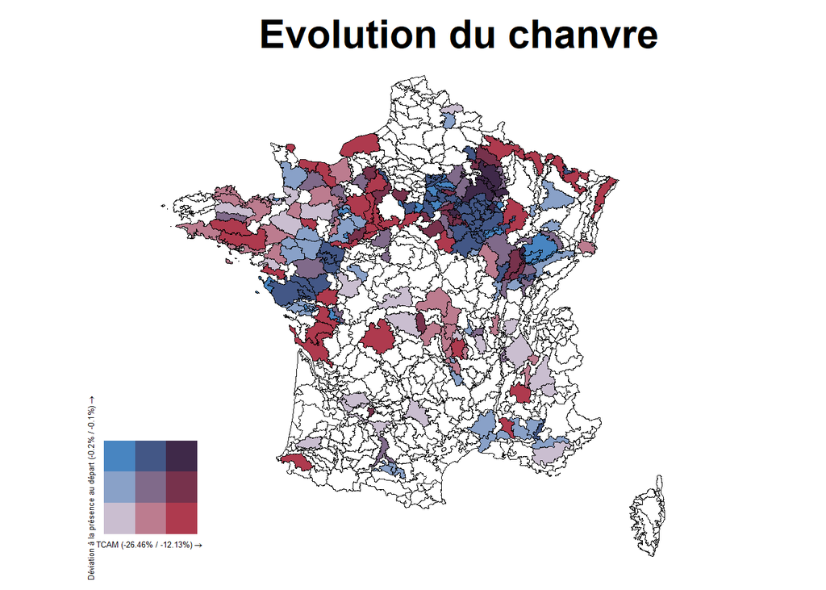

On remarque que le chanvre n’était pas cultivé dans toute l’hexagone en 2015 (zones blanches). C’est une culture historiquement développée dans l’est du bassin parisien (bleu) mais dont la surface (en %) tend à y progresser moins vite que dans d’autres territoires (en rouge).

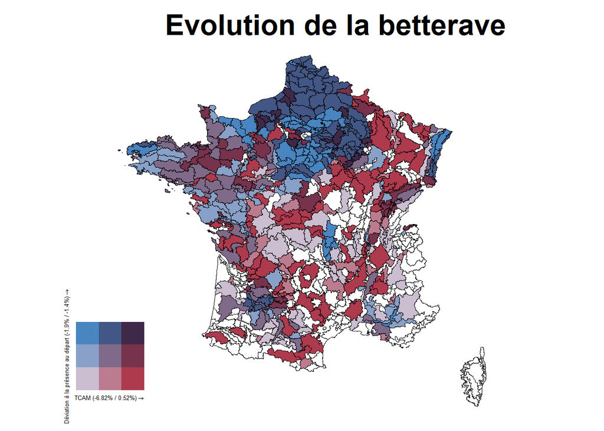

## D’autres cultures importantes

Nous allons brièvement nous intéresser à trois autres cultures. Elles interviendront bien plus dans l’analyse économétrique pour leur importance historique, leur présence dans la littérature récente et leur implantation spatialement hétérogène : le maïs, le blé et les vignes.

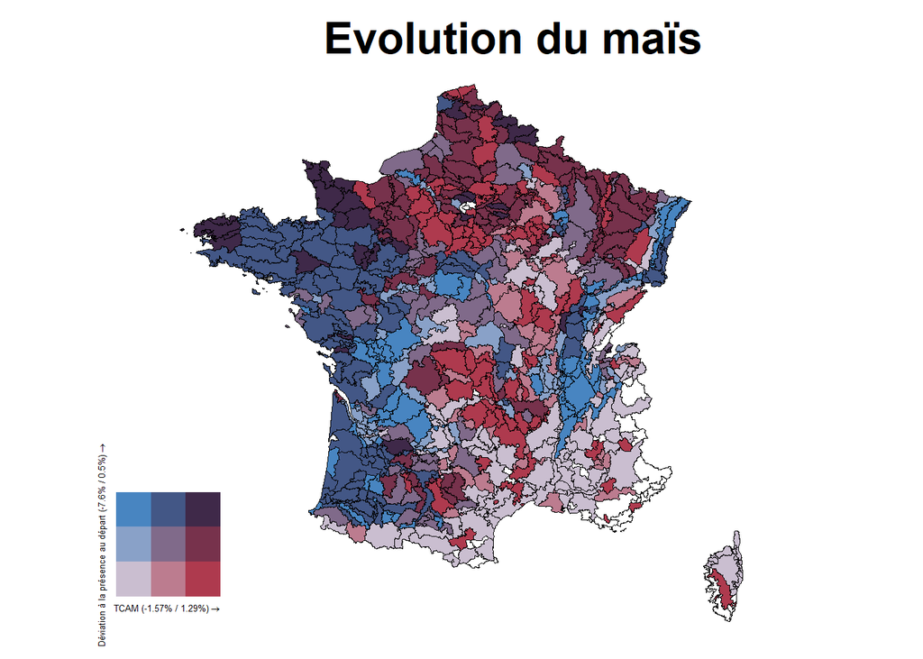

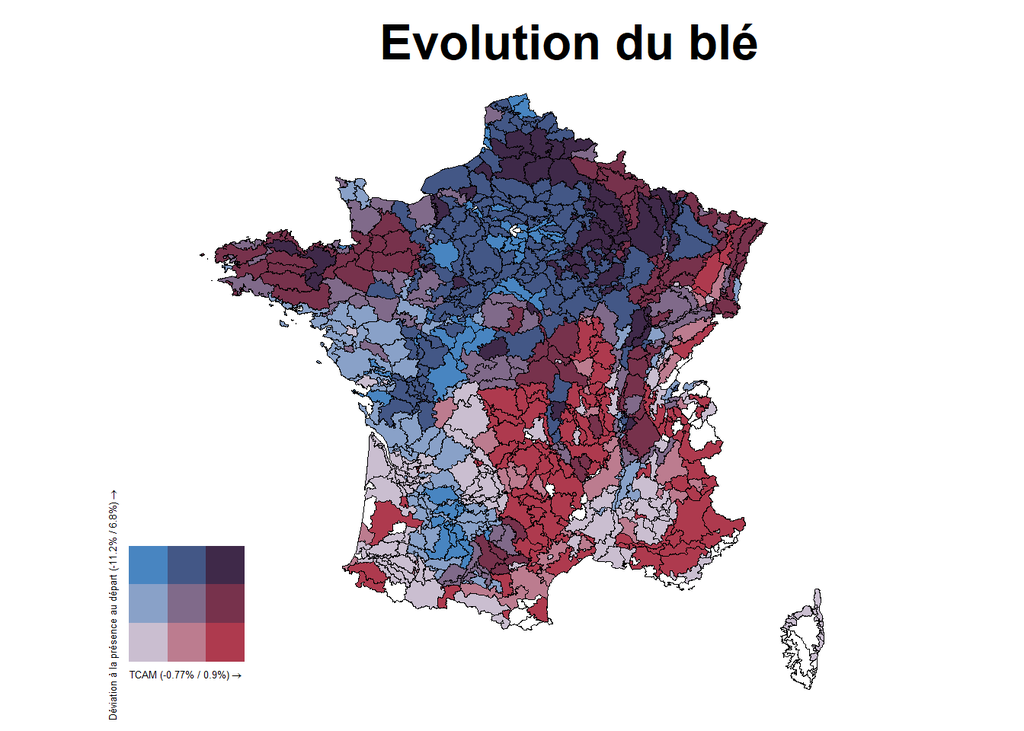

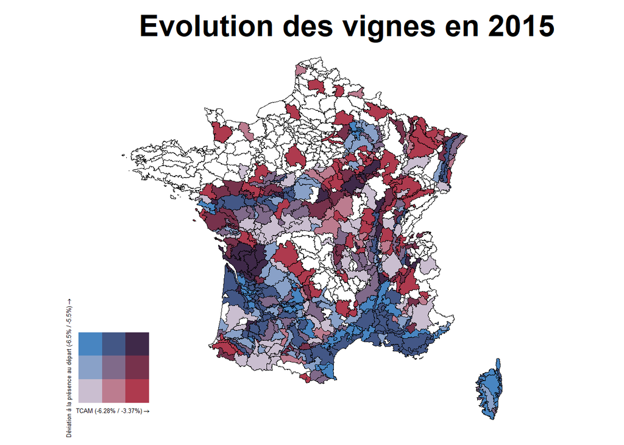

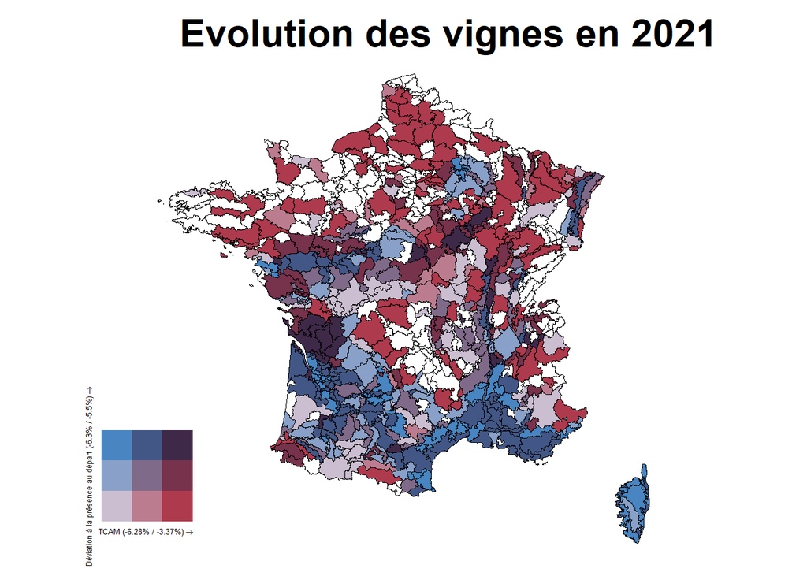

On observe chacune des cartes pour une année de référence paramétrée à 2015, sauf pour les vignes où on a aussi choisi de la montrer avec 2021 pour année de référence : on voit bien les territoires émergeants où la vigne commence à s’implanter (notamment les régions passant du blanc au rouge) !

# Des indices de biodiversité

Pour rappel, s’adapter correspond à adopter une démarche d’ajustement au climat actuel ou attendu, ainsi qu’à ses conséquences. L’adaptation en agriculture peut passer par différents mécanismes : augmentation la surface de plantation d’une culture (spécialiser) pour pouvoir absorber les chocs de perte de rendements ou planter plus de tout pour devenir plus résilient (diversification).

On cherche à identifier ces différentes trajectoires en étudiant deux indices de biodiversité : l’indice de Shannon et celui de Simpson.

## Indice de Shannon

Parfois appelé indice de Shannon-Wiener, c’est un indice allant généralement de 0 à 5 : plus il est grand plus une communauté est riche et diversifiée. Cet indice reflète deux dimensions de biodiversité : - La richesse des espèces : fait référence au nombre d’espèces - La diversité des espèces : fait référence à une relation entre nombre d’espèces et nombre d’individus en son sein.

On dit que < 2 : faible et > 3 : fort (ie le nombre d’espèces est aussi important que la variété et l’uniformité des concentrations de chaque espèce).

## Indice de Simpson

Si Shannon donne un aperçu de l’uniformité de la diversité sur une parcelle, Simpson met en évidence la présence d’espèces dominantes sur une parcelle.

Plus concrètement, l’indice de Simpson D est la probabilité que deux individus choisis au hasard soient de la même espèce : c’est pour cela qu’il prend des valeurs allant de 0 à 1. Ainsi, un $D$ grand signifie qu’une espèce est dominante. C’est pour cette raison que certains auteurs interprètent l’indice $1-D$ : plus il est grand, plus il y a de la diversité. Le package utilisé ici calcule justement $1-D$.

## Calcul des indices

Faisons un tour de ces deux indices en s’intéressant à leurs statistiques descriptives pour les cultures au niveau des PRA :

| variable | min | q1 | median | mean | q3 | max | sd |
| --- | --- | --- | --- | --- | --- | --- | --- |
| **Shannon** |  |  |  |  |  |  |  |
| shannon_2015 | 0.119 | 1.689 | 2.092 | 2.000 | 2.370 | 3.271 | 0.548 |
| shannon_2024 | 0.000 | 1.613 | 2.115 | 1.953 | 2.385 | 3.202 | 0.617 |
| tcam_shannon | -11.588 | -1.246 | -0.251 | -0.465 | 0.560 | 8.247 | 1.739 |
| **Simpson** |  |  |  |  |  |  |  |
| simpson_2015 | 0.034 | 0.683 | 0.794 | 0.740 | 0.843 | 0.939 | 0.157 |
| simpson_2024 | 0.000 | 0.637 | 0.796 | 0.720 | 0.850 | 0.942 | 0.188 |
| tcam_simpson | -15.075 | -0.883 | -0.074 | -0.494 | 0.446 | 11.155 | 1.864 |

Maintenant qu’on comprend un peu plus ce qui compose ces indices, on peut les visualiser via une nouvelle carte bivariée pour une analyse plus qualitative.

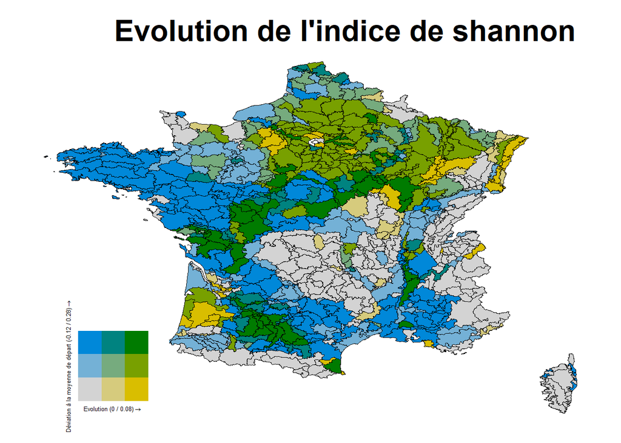

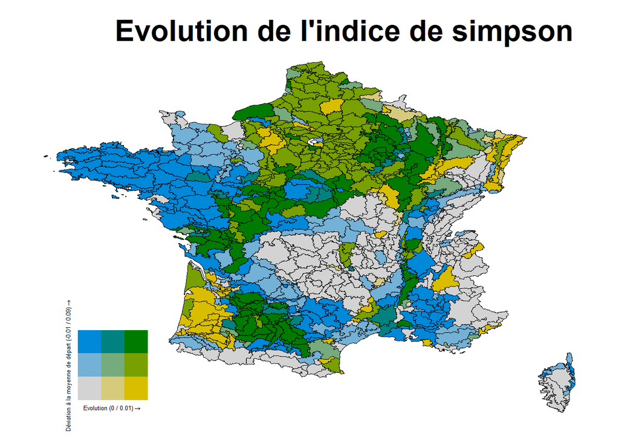

On peut faire un tableau récapitulatif des différentes dynamiques observables :

Grille d’interprétation croisée des indices de Shannon et Simpson

| Évolution de Shannon | Évolution de Simpson ($1-D$) | Interprétation écologique (Situation sur le terrain) |
| --- | --- | --- |
| En hausse ($\nearrow$) | En hausse ($\nearrow$) | Amélioration globale de la biodiversité. Le milieu s’enrichit en nouvelles espèces et/ou les effectifs deviennent plus homogènes (baisse de la dominance). |
| En baisse ($\searrow$) | En baisse ($\searrow$) | Dégradation globale / Perturbation. Perte d’espèces (souvent les plus fragiles) et/ou installation d’une forte dominance par une ou deux espèces opportunistes. |
| Stable ($\rightarrow$) | En hausse ($\nearrow$) | Rééquilibrage des forces en présence. La richesse spécifique (nombre d’espèces) n’a pas changé, mais les espèces dominantes perdent du terrain au profit des autres, rendant le milieu plus équitable. |
| Stable ($\rightarrow$) | En baisse ($\searrow$) | Début de monopolisation. Le nombre d’espèces reste identique, mais une ou deux espèces commencent à sur-dominer le milieu, réduisant l’équitabilité globale. |
| En hausse ($\nearrow$) | Stable ou en baisse | Arrivée d’espèces rares / colonisation discrète. De nouvelles espèces s’installent avec de très petits effectifs. Shannon le capte immédiatement (hausse), tandis que Simpson reste insensible car les e… |
| En baisse ($\searrow$) | Stable ($\rightarrow$) | Disparition discrète d’espèces rares. Le milieu perd des espèces qui étaient déjà très peu représentées. Simpson ne remarque rien (les dominants sont inchangés), mais Shannon décline. |

## Suggestions de mécanismes

En Bretagne et sur une partie du Pays de la Loire, on observe une baisse des deux indices ce qui traduit une perte de diversité culturale et l’installation d’une forte dominance. Cela reflète le processus qui a suivi la fin des quotas laitiers en 2008 puis 2015 qui a renforcé la polarisation de la production de lait en faveur des grandes exploitations bretonnes qui bénéficiaient d’économies d’échelle (Avignon & Guige (2023)). Cela a poussé à leur spécialisation et à la diminution de systèmes agricoles en polyculture et en élevage. Parallèlement, le recensement agricole de 2020 confirme une réduction du nombre d’exploitations, passant de 515 000 en 2010 à 416 000 en 2020 et mécaniquement accompagnée d’une hausse de la surface moyenne par exploitation.

Dans les zones de montagne en revanche (Alpes, Pyrénées, Massif central, Corse) les indices restent stables et bas. Ce n’est pas une surprise : ces zones sont historiquement dédiées au pastoralisme extensif, les terres arables y sont rares et les pratiques agricoles peu présentes par nature.

Enfin, le Bassin parisien se distingue par une hausse des deux indices, signalant un enrichissement de la biodiversité culturale. Plusieurs facteurs l’expliquent : la Stratégie nationale pour les protéines végétales de 2020 (pour l’indépendance protéinique face au soja importé) qui vise à doubler les surfaces de légumineuses (1 à 2 millions d’hectares d’ici 2030 (ie 8% de la surface utile) + préservation des surfaces oléagineuses à 2 millions d’hectares) et l’interdiction des néonicotinoïdes en 2023 qui a mené à la chute de la production de betterave et à l’allongement des rotations courtes traditionnelles (pour casser le cycle des bioagresseurs). Cette situation aurait donc pu bénéficier aux olégaineux et protéagineux. Ainsi, on peut expliquer cet accroissement de la diversité spécifiquement dans cette région par l’existence de grands champs fertiles et suffisamment productifs pour y développer ces cultures.

Maintenant qu’on a beaucoup observé et décrit ce qui a pu se passer, on peut passer à l’analyse économétrique.

# Analyse économétrique

Pour rappel, on cherche à capturer le rôle du changement climatique dans l’évolution des choix de cultures en France.

On s’inspire notamment des travaux de Cui (2020), Cui & Xie (2022) et Cui & Zhong (2024). C’est la façon dont les auteurs construisent leurs variables climatiques qui est intéressante dans ces papiers. Plutôt que d’utiliser des données météo annuelles, qui capturent surtout des chocs ponctuels, ils s’appuient sur des moyennes mobiles sur 30 ans et sur la longueur de la saison de croissance. Ce sont des indicateurs de tendance longue qui reflètent le dérèglement climatique structurel plutôt qu’un simple aléa météorologique d’une année sur l’autre. Ces travaux introduisent aussi la notion d’avantage comparatif régional (le fait que le réchauffement ne produit pas les mêmes effets partout). Une région initialement froide peut voir émerger de nouvelles cultures quand une région déjà chaude subit des pertes. C’est cette hétérogénéité que l’on cherchera à exploiter dans nos modèles.

## Test des données sur le Pays Basque

On peut d’abord tester nos données sur un territoire particulier afin de contrôler la logique des choses. Pour cela, on a choisi de s’intéresser à la PRA “MONTAGNE BASQUE - 64”, code 64140.

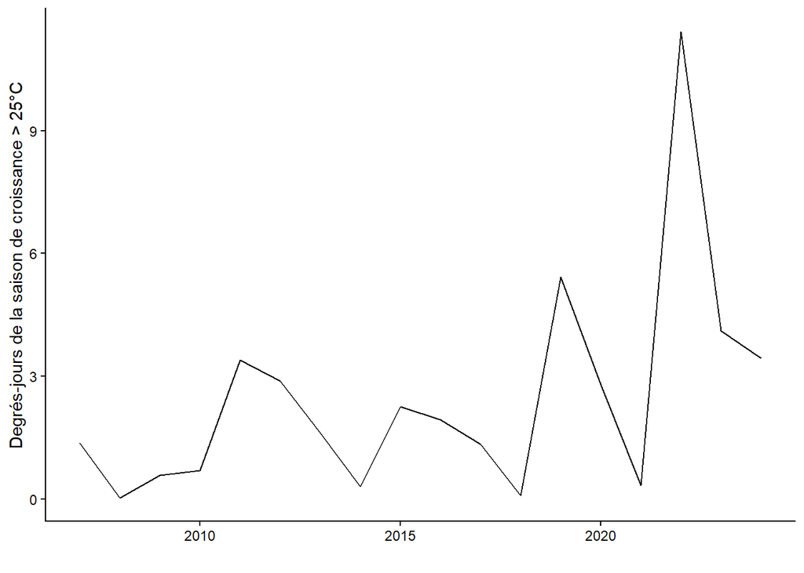

De même avec les niveaux de précipitations, le pic de 2013 correspond bien aux inondations importantes qu’ont connues le territoire cette année-là.

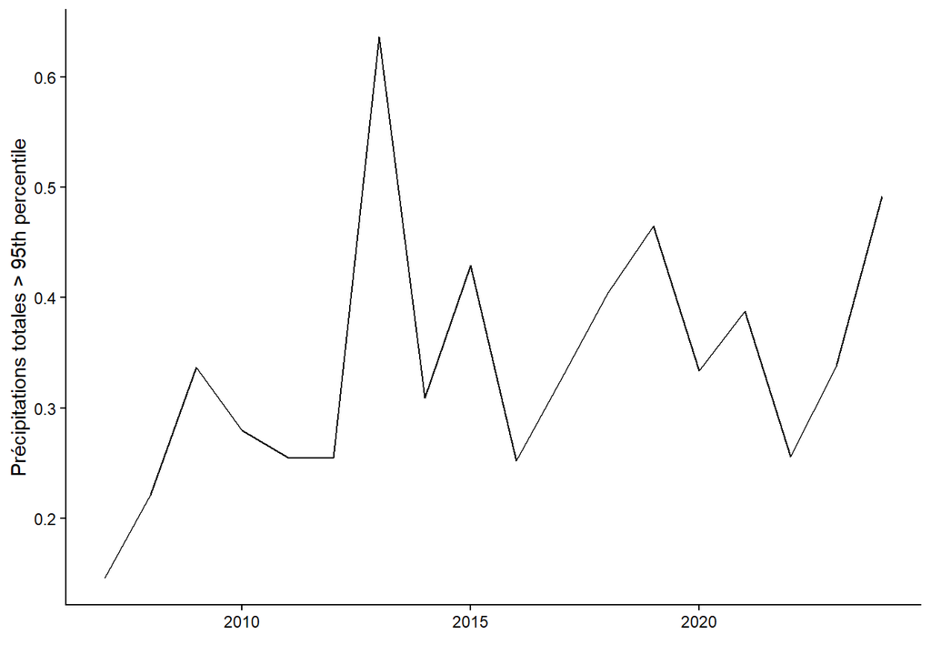

## Statistiques descriptives

Voici quelques statistiques descriptives (pour la température moyenne journalière) pour comprendre avec quelles données on travaille :

| variable | min | q1 | median | mean | q3 | max | sd |
| --- | --- | --- | --- | --- | --- | --- | --- |
| Tranche GSDD [0°C - 3°C] | 302.948 | 861.569 | 952.038 | 933.222 | 1027.662 | 1098.000 | 117.018 |
| Tranche GSDD [3°C - 6°C] | 300.852 | 817.239 | 897.987 | 889.665 | 976.327 | 1097.962 | 114.118 |
| Tranche GSDD [6°C - 9°C] | 257.957 | 714.731 | 786.021 | 784.768 | 863.815 | 1072.053 | 110.980 |
| Tranche GSDD [9°C - 12°C] | 79.494 | 569.830 | 628.890 | 630.439 | 692.925 | 948.181 | 97.885 |
| Tranche GSDD [12°C - 15°C] | 10.210 | 418.849 | 466.774 | 470.287 | 524.328 | 737.324 | 86.414 |
| Tranche GSDD [15°C - 18°C] | 0.426 | 251.371 | 304.272 | 311.268 | 376.807 | 581.218 | 90.755 |
| Tranche GSDD [18°C - 21°C] | 0.000 | 100.019 | 153.374 | 163.958 | 222.670 | 451.499 | 85.560 |
| Tranche GSDD [21°C - 24°C] | 0.000 | 25.072 | 52.140 | 65.471 | 91.511 | 332.677 | 53.913 |
| Tranche GSDD [24°C - 27°C] | 0.000 | 2.630 | 10.612 | 18.120 | 25.551 | 215.045 | 22.862 |
| Tranche GSDD [+27°C] | 0.000 | 0.000 | 0.186 | 2.792 | 2.653 | 94.233 | 6.375 |
| GSL | 101.030 | 290.789 | 323.592 | 316.276 | 349.177 | 366.000 | 40.541 |
| 1st GSL doy | 0.286 | 1.258 | 20.000 | 26.104 | 44.687 | 160.304 | 26.484 |
| PRCP totales annuelles | 299.713 | 746.291 | 860.545 | 913.358 | 1026.948 | 2131.231 | 248.789 |
| Taux de croissance des rendements potentiels | -1.000 | -0.070 | 0.000 | 0.473 | 0.012 | 997.627 | 12.538 |

## Modèles économétriques

Un premier modèle cherche à expliquer la surface d’une culture (en ha ou en %) par des “bins” de degrés-jours de 3°C durant la saison de croissance. Cette régression est complétée par des effets fixes année/PRA et par différentes variables de contrôle (précipitations, rendements potentiels).

De plus, on va pondérer nos observations par la part de la région qui cultive la culture à laquelle on s’intéresse afin d’accorder plus de poids aux régions les plus cultivatrices.

Un autre modèle fait la même chose qu’au premier mais utilise des seuils plus larges que ceux de 3°C pour les degrés-jours de la saison de croissance. De même, voici les résultats pour les surfaces (en %) du maïs, des vignes et du blé (maximum quotidien) :

Evolution du log de la surface de Maïs (en %)

|  | I | II | III | IV | V |
| --- | --- | --- | --- | --- | --- |
| (Intercept) | −4.259*** |  |  |  |  |
|  | (0.084) |  |  |  |  |
| Tranche GSDD [0°C - 3°C] | 0.001 | 0.002+ | −0.001*** | −0.001*** | −0.001*** |
|  | (0.001) | (0.001) | (0.000) | (0.000) | (0.000) |
| Tranche GSDD [3°C - 6°C] | −0.002 | −0.004* | 0.001*** | 0.002*** | 0.002*** |
|  | (0.002) | (0.002) | (0.000) | (0.000) | (0.000) |
| Tranche GSDD [6°C - 9°C] | 0.001 | 0.003** | −0.001*** | −0.001*** | −0.001*** |
|  | (0.001) | (0.001) | (0.000) | (0.000) | (0.000) |
| Tranche GSDD [9°C - 12°C] | 0.003*** | 0.001* | 0.001*** | 0.001*** | 0.000*** |
|  | (0.001) | (0.001) | (0.000) | (0.000) | (0.000) |
| Tranche GSDD [12°C - 15°C] | 0.000 | 0.002** | −0.000* | −0.000** | −0.000* |
|  | (0.001) | (0.001) | (0.000) | (0.000) | (0.000) |
| Tranche GSDD [15°C - 18°C] | 0.002*** | 0.003*** | −0.000** | −0.000** | −0.000** |
|  | (0.001) | (0.001) | (0.000) | (0.000) | (0.000) |
| Tranche GSDD [18°C - 21°C] | −0.003*** | −0.004*** | 0.000*** | 0.000** | 0.000** |
|  | (0.001) | (0.001) | (0.000) | (0.000) | (0.000) |
| Tranche GSDD [21°C - 24°C] | −0.002* | −0.001 | 0.000** | 0.000** | 0.000** |
|  | (0.001) | (0.001) | (0.000) | (0.000) | (0.000) |
| Tranche GSDD [24°C - 27°C] | 0.005*** | 0.003*** | 0.000 | 0.000 | 0.000 |
|  | (0.001) | (0.001) | (0.000) | (0.000) | (0.000) |
| Tranche GSDD [+27°C] | −0.002*** | −0.001*** | −0.001*** | −0.001*** | −0.001*** |
|  | (0.000) | (0.000) | (0.000) | (0.000) | (0.000) |
| PRCP totales annuelles |  |  |  | 0.000*** | 0.000*** |
|  |  |  |  | (0.000) | (0.000) |
| (PRCP totales annuelles)^2 |  |  |  | −0.000*** | −0.000*** |
|  |  |  |  | (0.000) | (0.000) |
| Année::2007:Taux rendement potentiel |  |  |  |  | −0.002 |
|  |  |  |  |  | (0.002) |
| Année::2008:Taux rendement potentiel |  |  |  |  | −0.003+ |
|  |  |  |  |  | (0.002) |
| Année::2009:Taux rendement potentiel |  |  |  |  | −0.003 |
|  |  |  |  |  | (0.002) |
| Année::2010:Taux rendement potentiel |  |  |  |  | −0.003* |
|  |  |  |  |  | (0.002) |
| Année::2011:Taux rendement potentiel |  |  |  |  | −0.002 |
|  |  |  |  |  | (0.002) |
| Année::2012:Taux rendement potentiel |  |  |  |  | −0.003+ |
|  |  |  |  |  | (0.002) |
| Année::2013:Taux rendement potentiel |  |  |  |  | −0.006*** |
|  |  |  |  |  | (0.002) |
| Année::2014:Taux rendement potentiel |  |  |  |  | −0.004* |
|  |  |  |  |  | (0.002) |
| Année::2015:Taux rendement potentiel |  |  |  |  | −0.005** |
|  |  |  |  |  | (0.002) |
| Année::2016:Taux rendement potentiel |  |  |  |  | −0.003+ |
|  |  |  |  |  | (0.002) |
| Année::2017:Taux rendement potentiel |  |  |  |  | −0.002 |
|  |  |  |  |  | (0.002) |
| Année::2018:Taux rendement potentiel |  |  |  |  | −0.002 |
|  |  |  |  |  | (0.002) |
| Année::2019:Taux rendement potentiel |  |  |  |  | −0.004** |
|  |  |  |  |  | (0.002) |
| Année::2020:Taux rendement potentiel |  |  |  |  | −0.003+ |
|  |  |  |  |  | (0.002) |
| Année::2021:Taux rendement potentiel |  |  |  |  | 0.000 |
|  |  |  |  |  | (0.002) |
| Année::2022:Taux rendement potentiel |  |  |  |  | 0.001 |
|  |  |  |  |  | (0.002) |
| Année::2023:Taux rendement potentiel |  |  |  |  | 0.002 |
|  |  |  |  |  | (0.002) |
| Num.Obs. | 12165 | 12165 | 12161 | 12161 | 12161 |
| R2 | 0.120 | 0.165 | 0.977 | 0.978 | 0.978 |
| R2 Adj. | 0.119 | 0.163 | 0.976 | 0.976 | 0.976 |
| FE: year |  | X | X | X | X |
| FE: code_insee |  |  | X | X | X |

+ p < 0.1, * p < 0.05, ** p < 0.01, *** p < 0.001

Evolution du log de la surface de Maïs (en %)

|  | I | II | III | IV | V |
| --- | --- | --- | --- | --- | --- |
| (Intercept) | −4.398*** |  |  |  |  |
|  | (0.077) |  |  |  |  |
| Tranche GSDD [0°C - 10°C] | 0.001*** | 0.001*** | −0.000*** | −0.000*** | −0.000*** |
|  | (0.000) | (0.000) | (0.000) | (0.000) | (0.000) |
| Tranche GSDD [10°C - 26°C] | 0.000*** | 0.000*** | 0.000*** | 0.000*** | 0.000*** |
|  | (0.000) | (0.000) | (0.000) | (0.000) | (0.000) |
| Tranche GSDD [+26°C] | −0.000** | −0.000 | −0.001*** | −0.001*** | −0.001*** |
|  | (0.000) | (0.000) | (0.000) | (0.000) | (0.000) |
| PRCP totales annuelles |  |  |  | 0.000*** | 0.000*** |
|  |  |  |  | (0.000) | (0.000) |
| (PRCP totales annuelles)^2 |  |  |  | −0.000*** | −0.000*** |
|  |  |  |  | (0.000) | (0.000) |
| Année::2007:Taux rendement potentiel |  |  |  |  | −0.003+ |
|  |  |  |  |  | (0.002) |
| Année::2008:Taux rendement potentiel |  |  |  |  | −0.004** |
|  |  |  |  |  | (0.002) |
| Année::2009:Taux rendement potentiel |  |  |  |  | −0.004** |
|  |  |  |  |  | (0.002) |
| Année::2010:Taux rendement potentiel |  |  |  |  | −0.004** |
|  |  |  |  |  | (0.002) |
| Année::2011:Taux rendement potentiel |  |  |  |  | −0.003 |
|  |  |  |  |  | (0.002) |
| Année::2012:Taux rendement potentiel |  |  |  |  | −0.004* |
|  |  |  |  |  | (0.002) |
| Année::2013:Taux rendement potentiel |  |  |  |  | −0.006*** |
|  |  |  |  |  | (0.002) |
| Année::2014:Taux rendement potentiel |  |  |  |  | −0.004* |
|  |  |  |  |  | (0.002) |
| Année::2015:Taux rendement potentiel |  |  |  |  | −0.005** |
|  |  |  |  |  | (0.002) |
| Année::2016:Taux rendement potentiel |  |  |  |  | −0.004* |
|  |  |  |  |  | (0.002) |
| Année::2017:Taux rendement potentiel |  |  |  |  | −0.002 |
|  |  |  |  |  | (0.002) |
| Année::2018:Taux rendement potentiel |  |  |  |  | −0.003* |
|  |  |  |  |  | (0.002) |
| Année::2019:Taux rendement potentiel |  |  |  |  | −0.005** |
|  |  |  |  |  | (0.002) |
| Année::2020:Taux rendement potentiel |  |  |  |  | −0.004* |
|  |  |  |  |  | (0.002) |
| Année::2021:Taux rendement potentiel |  |  |  |  | 0.000 |
|  |  |  |  |  | (0.002) |
| Année::2022:Taux rendement potentiel |  |  |  |  | −0.000 |
|  |  |  |  |  | (0.002) |
| Année::2023:Taux rendement potentiel |  |  |  |  | 0.002 |
|  |  |  |  |  | (0.002) |
| Num.Obs. | 12165 | 12165 | 12161 | 12161 | 12161 |
| R2 | 0.089 | 0.139 | 0.977 | 0.977 | 0.977 |
| R2 Adj. | 0.088 | 0.137 | 0.976 | 0.976 | 0.976 |
| FE: year |  | X | X | X | X |
| FE: code_insee |  |  | X | X | X |

+ p < 0.1, * p < 0.05, ** p < 0.01, *** p < 0.001

On remarque que les coefficients de l’interaction entre le rendement potentiel et l’effet fixe année ne sont significatifs que jusqu’en 2015. *FAUX : ça a changé depuis qu’on pondère nos régressions. On fait quand même comme si pour l’instant !*

Or, 2015 correspond également à la réforme des groupes de culture RPG, cette significativité ne serait issue que d’un changement administratif ? Pour vérifier cela, nous allons tirer au sort 10 PRA de façon aléatoire et dessiner l’évolution de leur surface dédiée au maïs.

[interactive chart not shown]

Evolution du log de la surface de Vignes (en %)

|  | I | II | III | IV |
| --- | --- | --- | --- | --- |
| (Intercept) | −5.466*** |  |  |  |
|  | (0.160) |  |  |  |
| Tranche GSDD [0°C - 3°C] | −0.013*** | −0.019*** | −0.000 | −0.000 |
|  | (0.003) | (0.003) | (0.000) | (0.000) |
| Tranche GSDD [3°C - 6°C] | 0.017*** | 0.027*** | 0.001+ | 0.001+ |
|  | (0.004) | (0.004) | (0.001) | (0.001) |
| Tranche GSDD [6°C - 9°C] | −0.008*** | −0.015*** | −0.001*** | −0.001*** |
|  | (0.002) | (0.003) | (0.000) | (0.000) |
| Tranche GSDD [9°C - 12°C] | 0.006*** | 0.011*** | 0.001** | 0.000* |
|  | (0.001) | (0.002) | (0.000) | (0.000) |
| Tranche GSDD [12°C - 15°C] | 0.006*** | 0.004** | 0.000 | 0.000 |
|  | (0.001) | (0.001) | (0.000) | (0.000) |
| Tranche GSDD [15°C - 18°C] | −0.008*** | −0.011*** | −0.000 | −0.000 |
|  | (0.001) | (0.001) | (0.000) | (0.000) |
| Tranche GSDD [18°C - 21°C] | 0.005*** | 0.011*** | −0.001** | −0.000* |
|  | (0.001) | (0.001) | (0.000) | (0.000) |
| Tranche GSDD [21°C - 24°C] | −0.001 | 0.000 | 0.002*** | 0.001*** |
|  | (0.001) | (0.001) | (0.000) | (0.000) |
| Tranche GSDD [24°C - 27°C] | 0.007*** | 0.005*** | −0.000 | 0.000 |
|  | (0.001) | (0.001) | (0.000) | (0.000) |
| Tranche GSDD [+27°C] | −0.002*** | −0.003*** | −0.000*** | −0.000*** |
|  | (0.000) | (0.000) | (0.000) | (0.000) |
| PRCP totales annuelles |  |  |  | 0.000** |
|  |  |  |  | (0.000) |
| (PRCP totales annuelles)^2 |  |  |  | −0.000 |
|  |  |  |  | (0.000) |
| Num.Obs. | 7933 | 7933 | 7912 | 7912 |
| R2 | 0.219 | 0.275 | 0.989 | 0.989 |
| R2 Adj. | 0.218 | 0.272 | 0.988 | 0.988 |
| FE: year |  | X | X | X |
| FE: code_insee |  |  | X | X |

+ p < 0.1, * p < 0.05, ** p < 0.01, *** p < 0.001

Evolution du log de la surface de Vignes (en %)

|  | I | II | III | IV |
| --- | --- | --- | --- | --- |
| (Intercept) | −6.369*** |  |  |  |
|  | (0.146) |  |  |  |
| Tranche GSDD [0°C - 10°C] | 0.000 | −0.000*** | −0.000 | −0.000** |
|  | (0.000) | (0.000) | (0.000) | (0.000) |
| Tranche GSDD [10°C - 26°C] | 0.002*** | 0.003*** | 0.000*** | 0.000*** |
|  | (0.000) | (0.000) | (0.000) | (0.000) |
| Tranche GSDD [+26°C] | −0.000 | −0.002*** | −0.000*** | −0.000*** |
|  | (0.000) | (0.000) | (0.000) | (0.000) |
| PRCP totales annuelles |  |  |  | 0.000*** |
|  |  |  |  | (0.000) |
| (PRCP totales annuelles)^2 |  |  |  | −0.000** |
|  |  |  |  | (0.000) |
| Num.Obs. | 7933 | 7933 | 7912 | 7912 |
| R2 | 0.194 | 0.250 | 0.989 | 0.989 |
| R2 Adj. | 0.194 | 0.248 | 0.988 | 0.988 |
| FE: year |  | X | X | X |
| FE: code_insee |  |  | X | X |

+ p < 0.1, * p < 0.05, ** p < 0.01, *** p < 0.001

Evolution du log de la surface de Blé (en %)

|  | I | II | III | IV | V |
| --- | --- | --- | --- | --- | --- |
| (Intercept) | −1.180*** |  |  |  |  |
|  | (0.065) |  |  |  |  |
| Tranche GSDD [0°C - 3°C] | 0.002** | 0.000 | −0.000*** | −0.001*** | −0.000** |
|  | (0.001) | (0.001) | (0.000) | (0.000) | (0.000) |
| Tranche GSDD [3°C - 6°C] | −0.001 | 0.003** | −0.000 | 0.000 | 0.000 |
|  | (0.001) | (0.001) | (0.000) | (0.000) | (0.000) |
| Tranche GSDD [6°C - 9°C] | 0.001+ | 0.000 | 0.001*** | 0.001*** | 0.001*** |
|  | (0.001) | (0.001) | (0.000) | (0.000) | (0.000) |
| Tranche GSDD [9°C - 12°C] | −0.005*** | −0.005*** | 0.000 | 0.000 | 0.000 |
|  | (0.000) | (0.000) | (0.000) | (0.000) | (0.000) |
| Tranche GSDD [12°C - 15°C] | 0.001* | −0.002*** | −0.000* | −0.000** | −0.000** |
|  | (0.000) | (0.001) | (0.000) | (0.000) | (0.000) |
| Tranche GSDD [15°C - 18°C] | 0.001 | 0.001** | −0.000 | −0.000** | −0.000*** |
|  | (0.000) | (0.001) | (0.000) | (0.000) | (0.000) |
| Tranche GSDD [18°C - 21°C] | 0.002*** | 0.003*** | 0.000** | 0.000** | 0.000** |
|  | (0.000) | (0.001) | (0.000) | (0.000) | (0.000) |
| Tranche GSDD [21°C - 24°C] | 0.000 | 0.002** | 0.000 | 0.000 | 0.000 |
|  | (0.001) | (0.001) | (0.000) | (0.000) | (0.000) |
| Tranche GSDD [24°C - 27°C] | −0.006*** | −0.008*** | −0.000** | −0.000*** | −0.000*** |
|  | (0.001) | (0.001) | (0.000) | (0.000) | (0.000) |
| Tranche GSDD [+27°C] | 0.002*** | 0.002*** | 0.000*** | 0.000*** | 0.000*** |
|  | (0.000) | (0.000) | (0.000) | (0.000) | (0.000) |
| PRCP totales annuelles |  |  |  | −0.001*** | −0.001*** |
|  |  |  |  | (0.000) | (0.000) |
| (PRCP totales annuelles)^2 |  |  |  | 0.000*** | 0.000*** |
|  |  |  |  | (0.000) | (0.000) |
| Année::2007:Taux rendement potentiel |  |  |  |  | −0.171*** |
|  |  |  |  |  | (0.034) |
| Année::2008:Taux rendement potentiel |  |  |  |  | −0.080* |
|  |  |  |  |  | (0.040) |
| Année::2009:Taux rendement potentiel |  |  |  |  | −0.318*** |
|  |  |  |  |  | (0.040) |
| Année::2010:Taux rendement potentiel |  |  |  |  | −0.102** |
|  |  |  |  |  | (0.033) |
| Année::2011:Taux rendement potentiel |  |  |  |  | −0.209*** |
|  |  |  |  |  | (0.038) |
| Année::2012:Taux rendement potentiel |  |  |  |  | −0.252*** |
|  |  |  |  |  | (0.040) |
| Année::2013:Taux rendement potentiel |  |  |  |  | −0.003 |
|  |  |  |  |  | (0.031) |
| Année::2014:Taux rendement potentiel |  |  |  |  | 0.049 |
|  |  |  |  |  | (0.035) |
| Année::2015:Taux rendement potentiel |  |  |  |  | 0.121*** |
|  |  |  |  |  | (0.032) |
| Année::2016:Taux rendement potentiel |  |  |  |  | 0.012 |
|  |  |  |  |  | (0.028) |
| Année::2017:Taux rendement potentiel |  |  |  |  | 0.111*** |
|  |  |  |  |  | (0.029) |
| Année::2018:Taux rendement potentiel |  |  |  |  | 0.025 |
|  |  |  |  |  | (0.029) |
| Année::2019:Taux rendement potentiel |  |  |  |  | 0.086*** |
|  |  |  |  |  | (0.023) |
| Année::2020:Taux rendement potentiel |  |  |  |  | −0.048* |
|  |  |  |  |  | (0.022) |
| Année::2021:Taux rendement potentiel |  |  |  |  | 0.014 |
|  |  |  |  |  | (0.020) |
| Année::2022:Taux rendement potentiel |  |  |  |  | 0.010 |
|  |  |  |  |  | (0.019) |
| Année::2023:Taux rendement potentiel |  |  |  |  | 0.041* |
|  |  |  |  |  | (0.019) |
| Num.Obs. | 12228 | 12228 | 12226 | 12226 | 12226 |
| R2 | 0.121 | 0.157 | 0.977 | 0.977 | 0.978 |
| R2 Adj. | 0.121 | 0.155 | 0.976 | 0.976 | 0.976 |
| FE: year |  | X | X | X | X |
| FE: code_insee |  |  | X | X | X |

+ p < 0.1, * p < 0.05, ** p < 0.01, *** p < 0.001

Evolution du log de la surface de Blé (en %)

|  | I | II | III | IV | V |
| --- | --- | --- | --- | --- | --- |
| (Intercept) | −0.887*** |  |  |  |  |
|  | (0.061) |  |  |  |  |
| Tranche GSDD [0°C - 10°C] | −0.000 | 0.000* | 0.000*** | 0.000*** | 0.000*** |
|  | (0.000) | (0.000) | (0.000) | (0.000) | (0.000) |
| Tranche GSDD [10°C - 26°C] | −0.000*** | −0.000*** | 0.000+ | −0.000 | −0.000+ |
|  | (0.000) | (0.000) | (0.000) | (0.000) | (0.000) |
| Tranche GSDD [+26°C] | −0.001*** | −0.001*** | 0.000** | 0.000* | 0.000** |
|  | (0.000) | (0.000) | (0.000) | (0.000) | (0.000) |
| PRCP totales annuelles |  |  |  | −0.001*** | −0.001*** |
|  |  |  |  | (0.000) | (0.000) |
| (PRCP totales annuelles)^2 |  |  |  | 0.000*** | 0.000*** |
|  |  |  |  | (0.000) | (0.000) |
| Année::2007:Taux rendement potentiel |  |  |  |  | −0.174*** |
|  |  |  |  |  | (0.034) |
| Année::2008:Taux rendement potentiel |  |  |  |  | −0.081* |
|  |  |  |  |  | (0.040) |
| Année::2009:Taux rendement potentiel |  |  |  |  | −0.350*** |
|  |  |  |  |  | (0.039) |
| Année::2010:Taux rendement potentiel |  |  |  |  | −0.137*** |
|  |  |  |  |  | (0.032) |
| Année::2011:Taux rendement potentiel |  |  |  |  | −0.187*** |
|  |  |  |  |  | (0.038) |
| Année::2012:Taux rendement potentiel |  |  |  |  | −0.199*** |
|  |  |  |  |  | (0.039) |
| Année::2013:Taux rendement potentiel |  |  |  |  | 0.053+ |
|  |  |  |  |  | (0.030) |
| Année::2014:Taux rendement potentiel |  |  |  |  | 0.075* |
|  |  |  |  |  | (0.034) |
| Année::2015:Taux rendement potentiel |  |  |  |  | 0.166*** |
|  |  |  |  |  | (0.032) |
| Année::2016:Taux rendement potentiel |  |  |  |  | 0.060* |
|  |  |  |  |  | (0.027) |
| Année::2017:Taux rendement potentiel |  |  |  |  | 0.087** |
|  |  |  |  |  | (0.030) |
| Année::2018:Taux rendement potentiel |  |  |  |  | 0.070* |
|  |  |  |  |  | (0.029) |
| Année::2019:Taux rendement potentiel |  |  |  |  | 0.085*** |
|  |  |  |  |  | (0.024) |
| Année::2020:Taux rendement potentiel |  |  |  |  | −0.060** |
|  |  |  |  |  | (0.022) |
| Année::2021:Taux rendement potentiel |  |  |  |  | 0.021 |
|  |  |  |  |  | (0.020) |
| Année::2022:Taux rendement potentiel |  |  |  |  | 0.014 |
|  |  |  |  |  | (0.019) |
| Année::2023:Taux rendement potentiel |  |  |  |  | 0.041* |
|  |  |  |  |  | (0.019) |
| Num.Obs. | 12228 | 12228 | 12226 | 12226 | 12226 |
| R2 | 0.056 | 0.070 | 0.977 | 0.977 | 0.978 |
| R2 Adj. | 0.055 | 0.069 | 0.975 | 0.975 | 0.976 |
| FE: year |  | X | X | X | X |
| FE: code_insee |  |  | X | X | X |

+ p < 0.1, * p < 0.05, ** p < 0.01, *** p < 0.001

On peut aussi schématiquement visualiser ces résultats (pour le maïs par exemple) :

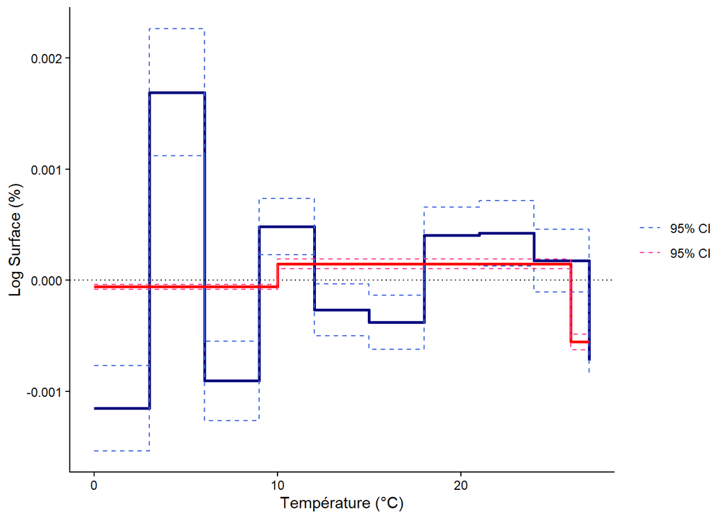

## Etude de la répartition des résidus

Mais, au-delà de l’agriculteur lui-même, une question nous intéresse particulièrement : quels rôles jouent les firmes agroindustrielles dans ces décisions ? Dans quelle mesure l’ariculteur décide-t-il seul ? Quand est-ce qu’il peut décider de manière isolée ? Quand-est-ce qu’un transformateur va jouer un rôle prépondérant ? De plus, on sait que les prix peuvent varier localement et donc intervenir dans le processus de décision de l’agriculteur. Visualiser la répartition des résidus peut potentiellement dévoiler des motifs révélateurs de ces mécanismes.

Les exemples qui vont suivre sont ceux du maïs (pour 2024 et on prend 2007 comme année de référence).

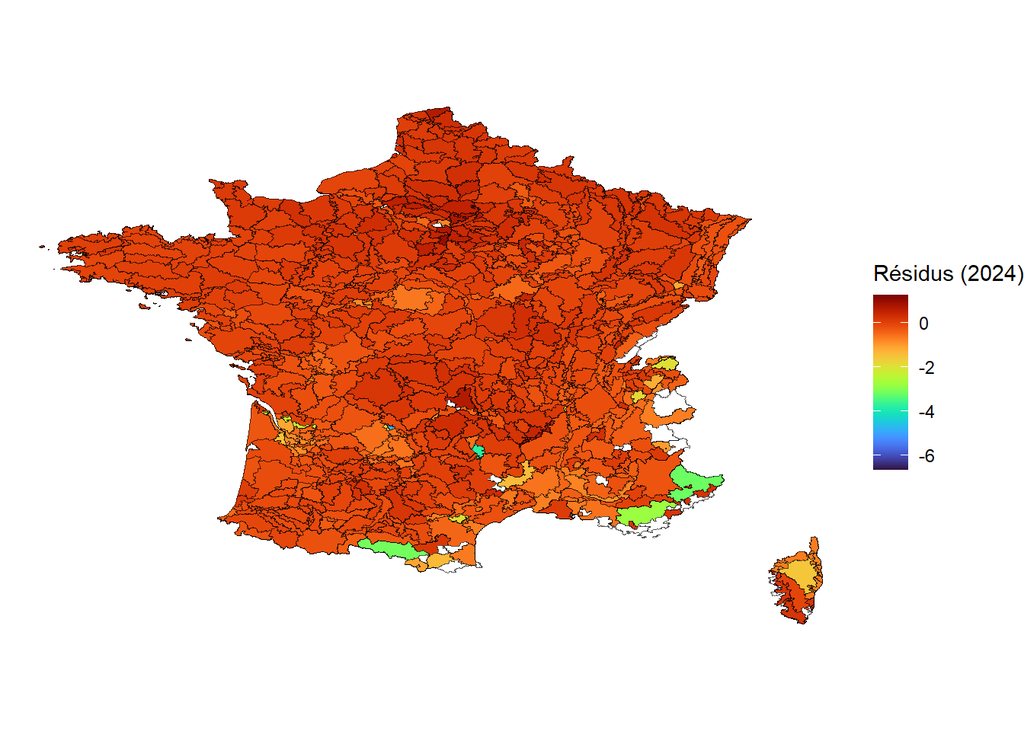

On aimerait également observer la répartition spatiale des résidus en fonction de l’importance du territoire dans la plantation de la culture : c’est pour cela qu’on fait encore appel à une carte bivariée.

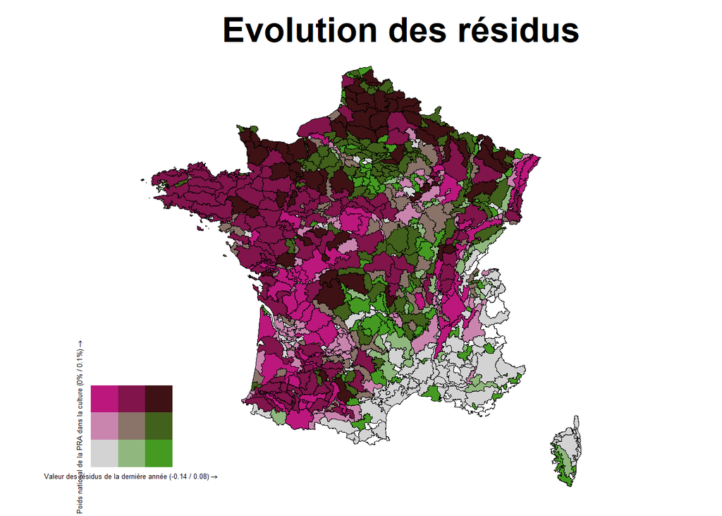